# Operating Characteristics of Multiplier Resampling (MR) — FB / MR (IJ) / MR (field) combined

# 15 MR (field) diagnostics

The field-calibrated interval’s own summaries (task `TASK_mr_field_section7_2026-09-05`, Stage 3 layout): two-sided 95% coverage with Wilson intervals (the paper’s primary convention, F4), one-sided lower coverage as the supplementary read, retained bias of the de-biased estimate $\tilde\beta$ and the shrunk-field `est2` against the conditional target $\beta(\widehat H)$ (log-HR and SD units), the $\lambda$-SD/SD calibration ratio, and the Monte Carlo draw-usage counts.

When the render ran with `field_complement = TRUE` (`FS_S7_FIELD_COMPLEMENT=TRUE`; `TASK_mr_field_complement_2026-09-06`) the same summaries follow for the complement $\widehat H^{c}$, evaluated on the same outer/inner draws and winners as the harm field with the complement’s own influence. Its exposed limit is the **upper** bound (a benefit claim “HR in $\widehat H^{c}$ is at most $U$”): the one-sided coverage in the complement block is $\beta(\widehat H^{c}) \le U$ for every estimator, and the display uses `side = "upper"`.

```r
if (run_smoke && !is.null(results) && any(is.finite(results$fld_H_est2))) {
  rF <- results[results$detected == 1, , drop = FALSE]

  # Wilson 95% interval for a coverage proportion (paper convention).
  .wilson <- function(x, n, z = qnorm(0.975)) {
    if (!is.finite(x) || !is.finite(n) || n <= 0) return(c(NA_real_, NA_real_))
    ctr <- (x + z^2 / (2 * n)) / (1 + z^2 / n)
    hw  <- z * sqrt(x * (1 - x) / n + z^2 / (4 * n^2)) / (1 + z^2 / n)
    c(ctr - hw, ctr + hw)
  }
  .cov_n <- function(target, lo, hi) {           # coverage + its denominator
    target <- rep_len(target, length(lo))
    ok <- is.finite(target) & is.finite(lo) & is.finite(hi)
    if (!any(ok)) return(c(NA_real_, 0L))
    c(mean(target[ok] >= lo[ok] & target[ok] <= hi[ok]), sum(ok))
  }
  .cov1_n <- function(target, b1, side = "lower") {   # one-sided: target >= lower bound,
    target <- rep_len(target, length(b1))               # or target <= upper bound
    ok <- is.finite(target) & is.finite(b1)
    if (!any(ok)) return(c(NA_real_, 0L))
    c(if (identical(side, "upper")) mean(target[ok] <= b1[ok])
      else mean(target[ok] >= b1[ok]), sum(ok))
  }
  z95 <- qnorm(0.95)

  cov_rows <- function(suffix, tgt_cde, tgt_marg) {
    keys <- est_keys_for(rF, suffix)
    or_est <- rF[[paste0("or_", suffix, "_est")]]
    bH_est <- rF[[paste0("betaHhat_", suffix)]]
    tgt <- list(oracle = or_est, betaHhat = bH_est, cde = tgt_cde, marg = tgt_marg)
    do.call(rbind, lapply(names(keys), function(lab) {
      k  <- keys[[lab]]
      ec <- .est_cols(rF, k, suffix)
      # One-sided 95% bound, on the block's exposed side: the harm block's
      # LOWER bound (harm claim), the complement's UPPER bound (benefit claim
      # "at most U"; TASK_mr_field_complement_2026-09-06).  The field stores
      # its own (lambda q95 / q05 inversion); the normal-based estimators
      # derive exp(log est -/+ z95 * se_beta) -- the same construction as
      # their two-sided bounds, so this is a convention, not a new model.
      side <- if (identical(suffix, "Hc")) "upper" else "lower"
      sgn  <- if (identical(side, "upper")) 1 else -1
      b1 <- if (k == "fld") rF[[paste0("fld_", suffix, if (side == "upper") "_up1s" else "_lo1s")]]
            else { seb <- .get_se(rF, k, suffix)
                   ifelse(is.finite(ec$e) & is.finite(seb) & ec$e > 0,
                          exp(log(ec$e) + sgn * z95 * seb), NA_real_) }
      do.call(rbind, lapply(names(tgt), function(tn) {
        c2 <- .cov_n(tgt[[tn]], ec$lo, ec$hi)
        w  <- .wilson(c2[1], c2[2])
        c1 <- .cov1_n(tgt[[tn]], b1, side)
        data.frame(Block = if (suffix == "H") "Harm Ĥ" else "Complement Ĥᶜ",
                   Estimator = lab, Target = tn,
                   n = as.integer(c2[2]), Cov2s = c2[1],
                   W_lo = w[1], W_hi = w[2], Cov1s = c1[1], Side = side,
                   stringsAsFactors = FALSE)
      }))
    }))
  }
  cw <- rbind(cov_rows("H",  truth$cde_H,  truth$marg_H),
              cov_rows("Hc", truth$cde_Hc, truth$marg_Hc))
  gt(cw, groupname_col = "Block") |>
    tab_header(title = "95% coverage with Wilson intervals (two-sided primary; one-sided supplementary)",
               subtitle = "Targets: per-replicate oracle; beta(Hhat) (conditional, primary); CDE; marginal") |>
    fmt_number(columns = c(Cov2s, W_lo, W_hi, Cov1s), decimals = 3) |>
    cols_label(Cov2s = "2-sided cov", W_lo = "Wilson lo", W_hi = "Wilson hi",
               Cov1s = "1-sided cov", Side = "1-sided bound") |>
    tab_footnote(footnote = md(paste(
      "Wilson interval on the two-sided coverage proportion (paper convention, primary; F4).",
      "One-sided coverage on the block's exposed side -- harm block: share of replicates with target >= the 95% LOWER bound;",
      "complement block: share with target <= the 95% UPPER bound (benefit claim; TASK_mr_field_complement_2026-09-06).",
      "The field rows use their stored `lower_1s` / `upper_1s` (lambda q95 / q05 inversion); the normal-based rows use exp(log est -/+ 1.645 se).")))
}
```

95% coverage with Wilson intervals (two-sided primary; one-sided supplementary)

Targets: per-replicate oracle; beta(Hhat) (conditional, primary); CDE; marginal

| Estimator | Target | n | 2-sided cov | Wilson lo | Wilson hi | 1-sided cov | 1-sided bound |
| --- | --- | --- | --- | --- | --- | --- | --- |
| Harm Ĥ |  |  |  |  |  |  |  |
| oracle | oracle | 1999 | 1.000 | 0.998 | 1.000 | 1.000 | lower |
| oracle | betaHhat | 1999 | 0.781 | 0.762 | 0.798 | 0.689 | lower |
| oracle | cde | 1999 | 0.929 | 0.917 | 0.940 | 0.982 | lower |
| oracle | marg | 1999 | 0.946 | 0.936 | 0.956 | 0.924 | lower |
| naive | oracle | 1999 | 0.949 | 0.939 | 0.958 | 0.891 | lower |
| naive | betaHhat | 1999 | 0.604 | 0.583 | 0.626 | 0.472 | lower |
| naive | cde | 1999 | 0.959 | 0.950 | 0.967 | 0.921 | lower |
| naive | marg | 1999 | 0.888 | 0.873 | 0.901 | 0.796 | lower |
| MR (IJ) | oracle | 1999 | 0.980 | 0.973 | 0.986 | 0.999 | lower |
| MR (IJ) | betaHhat | 1999 | 0.977 | 0.970 | 0.983 | 0.985 | lower |
| MR (IJ) | cde | 1999 | 0.876 | 0.861 | 0.890 | 0.999 | lower |
| MR (IJ) | marg | 1999 | 0.958 | 0.949 | 0.966 | 0.998 | lower |
| MR (field) | oracle | 1999 | 0.871 | 0.856 | 0.885 | 0.997 | lower |
| MR (field) | betaHhat | 1999 | 0.926 | 0.914 | 0.937 | 0.975 | lower |
| MR (field) | cde | 1999 | 0.698 | 0.677 | 0.718 | 0.996 | lower |
| MR (field) | marg | 1999 | 0.832 | 0.815 | 0.848 | 0.993 | lower |
| Complement Ĥᶜ |  |  |  |  |  |  |  |
| oracle | oracle | 1999 | 1.000 | 0.998 | 1.000 | 1.000 | upper |
| oracle | betaHhat | 1999 | 0.832 | 0.815 | 0.848 | 0.750 | upper |
| oracle | cde | 1999 | 0.929 | 0.917 | 0.939 | 0.979 | upper |
| oracle | marg | 1999 | 0.949 | 0.939 | 0.958 | 0.913 | upper |
| naive | oracle | 1999 | 0.995 | 0.991 | 0.998 | 0.997 | upper |
| naive | betaHhat | 1999 | 0.854 | 0.838 | 0.869 | 0.784 | upper |
| naive | cde | 1999 | 0.870 | 0.855 | 0.884 | 0.976 | upper |
| naive | marg | 1999 | 0.930 | 0.918 | 0.941 | 0.922 | upper |
| MR (IJ) | oracle | 1999 | 1.000 | 0.998 | 1.000 | 1.000 | upper |
| MR (IJ) | betaHhat | 1999 | 1.000 | 0.998 | 1.000 | 0.995 | upper |
| MR (IJ) | cde | 1999 | 0.991 | 0.986 | 0.994 | 1.000 | upper |
| MR (IJ) | marg | 1999 | 0.998 | 0.996 | 0.999 | 0.999 | upper |
| MR (field) | oracle | 1999 | 0.957 | 0.948 | 0.965 | 0.999 | upper |
| MR (field) | betaHhat | 1999 | 0.925 | 0.913 | 0.936 | 0.902 | upper |
| MR (field) | cde | 1999 | 0.685 | 0.665 | 0.705 | 0.992 | upper |
| MR (field) | marg | 1999 | 0.840 | 0.824 | 0.856 | 0.964 | upper |

Wilson interval on the two-sided coverage proportion (paper convention, primary; F4). One-sided coverage on the block’s exposed side – harm block: share of replicates with target >= the 95% LOWER bound; complement block: share with target <= the 95% UPPER bound (benefit claim; TASK_mr_field_complement_2026-09-06). The field rows use their stored `lower_1s` / `upper_1s` (lambda q95 / q05 inversion); the normal-based rows use exp(log est -/+ 1.645 se).

```
Table: Bias vs coverage, harm block: b = retained bias / empirical SD, r = mean SE / empirical SD (log scale); *_ref = Gaussian bookkeeping prediction at (b, r).

|cell           |estimator |    n|      b|     r|  cov1|  cov2| cov1_ref| cov2_ref|
|:--------------|:---------|----:|------:|-----:|-----:|-----:|--------:|--------:|
|hr=1.50, n=500 |mr        | 1999| -0.015| 1.322| 0.985| 0.977|    0.986|    0.990|
|hr=1.50, n=500 |fld       | 1999| -0.197| 1.110| 0.975| 0.926|    0.978|    0.967|
```

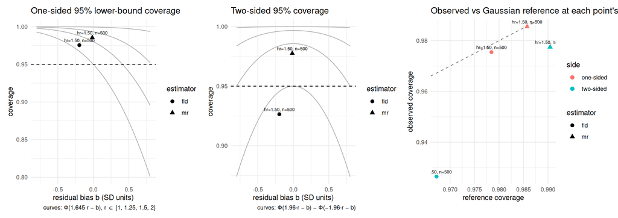

```r
# Bias-vs-coverage display for THIS cell (TASK_bias_coverage_display_2026-09-06):
# one point per estimator against the Gaussian bookkeeping reference.  The
# cross-cell version lives in summary_bias_coverage.qmd.
if (run_smoke && !is.null(results) && any(is.finite(results$fld_H_est2))) {
  .ests_H <- if (isTRUE(show_winner_rows) && "mr_H_se_w" %in% names(results) &&
                 any(is.finite(results$mr_H_se_w)))
    c("mr", "mr_w", "mr_wf", "fld") else c("mr", "fld")
  bc <- fs_sim_bias_coverage(results, block = "H", estimators = .ests_H)
  bc$cell <- sprintf("hr=%.2f, n=%d%s", target_hr_harm, n_sample,
                     if (k_random_noise > 0) sprintf(", +%d noise", k_random_noise) else "")
  print(knitr::kable(bc[, c("cell", "estimator", "n", "b", "r", "cov1", "cov2",
                            "cov1_ref", "cov2_ref")], digits = 3,
    caption = "Bias vs coverage, harm block: b = retained bias / empirical SD, r = mean SE / empirical SD (log scale); *_ref = Gaussian bookkeeping prediction at (b, r)."))
  print(fs_plot_bias_coverage(bc))
}
```